# ML_2_Summary

### Example 2

```r
# Local Regression as building blocks with GAM using lo()
library(gam)
```

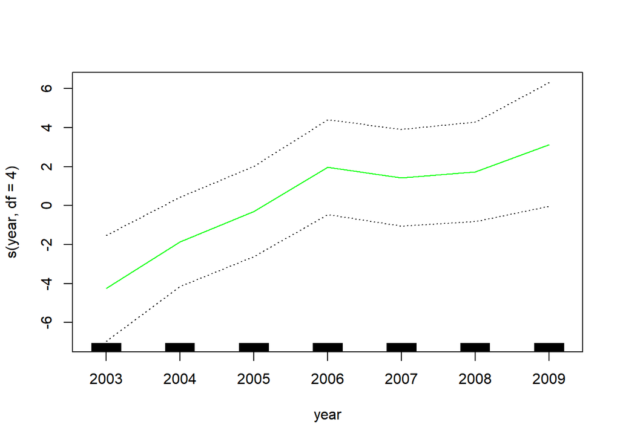

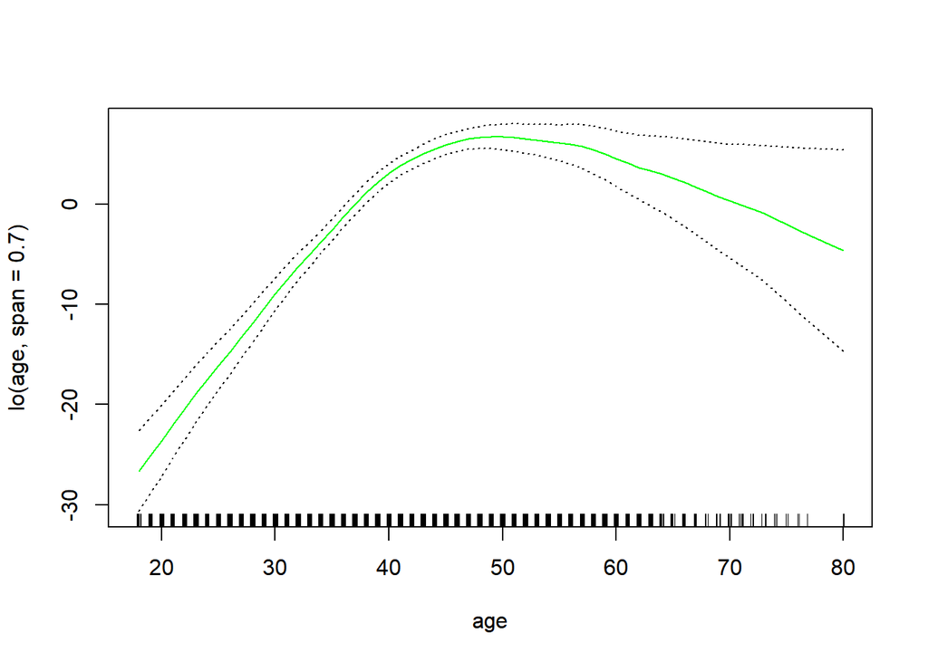

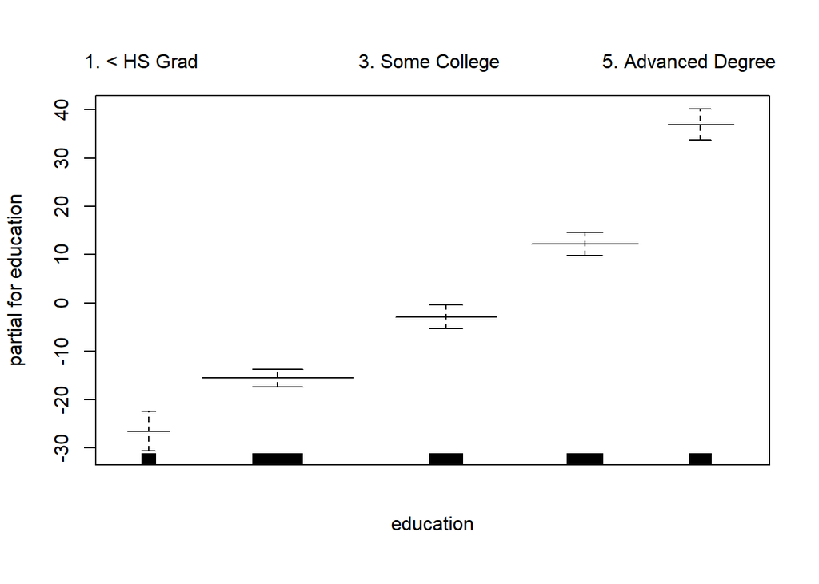

```r
gam.lo = gam(wage~s(year, df = 4) + lo(age, span = 0.7) + education,
             data = Wage)
plot(gam.lo, se = TRUE, col = "green")
```

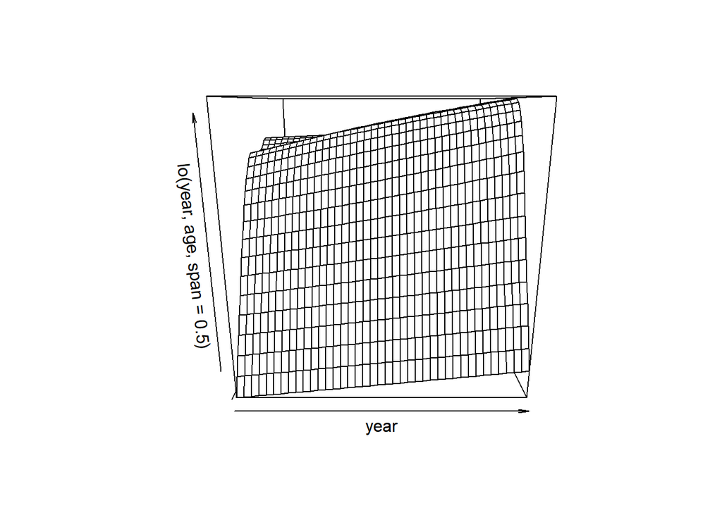

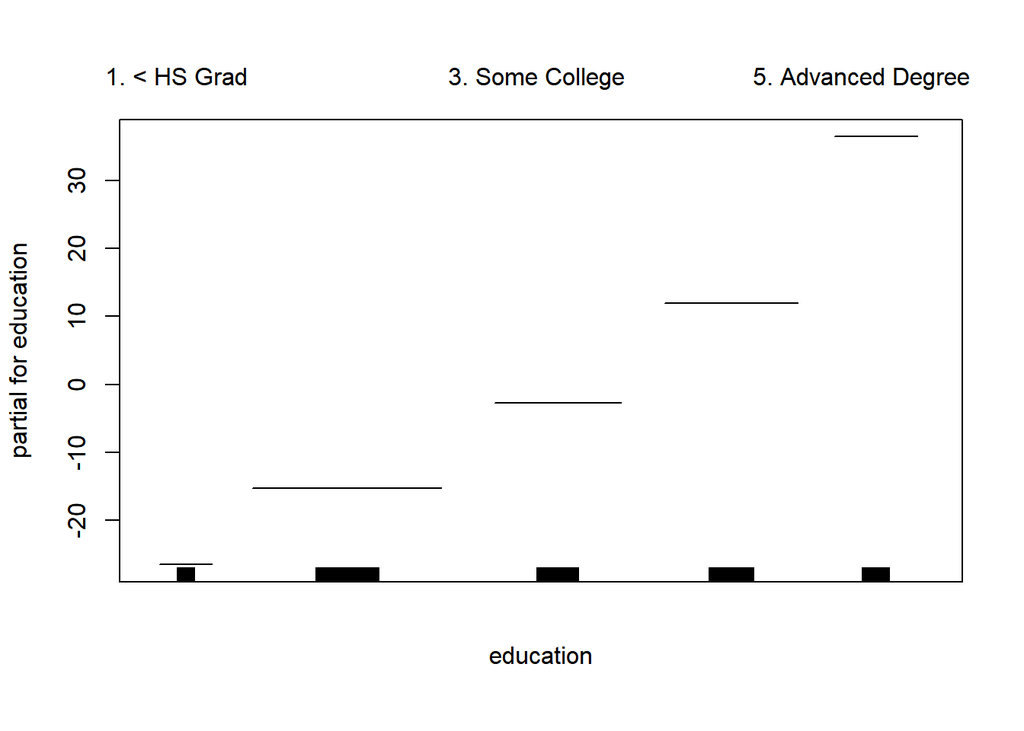

```r
# We have used local regression on the age term with a span of 0.7
# The lo() function can create interactions before galling the gam() function

gam.lo.i = gam(wage~lo(year, age, span = 0.5)+education, data = Wage)
# This fits a 2 term model. The first term is an interaction between year and age, by a local regression surface.

## Plot the resulting 2 dim surface
library(akima)
plot(gam.lo.i)
```

## GAM

Author: Akram Bijapuri

### Summary/description:

Generalized Additive Models allow us to fit a non-linear smoothing function (smoothing spline, natural splining, poly, etc.) to each of the variables(X) at one time.

GAMS maintain additivity which means you can add different functions to each variable while adding to examine each effect on an X variable when you make a function change or add another variable while holding all of the other variables constant. This allows for easy comparison through multiple models.

In basic terms: you can apply smoothing to one variable (“s(Blah, df=4)”), then add polynomial function to another Xvariable (“poly(Blah2,3)”), then add local regression to another xVariable (“lo(Blah3,df)”) etc. You can keep doing this, or you can start anova testing to see which one has the best significance (meaning you should use that). This allows you to find best model.

You can use combine qualitative and quantitative variables(X) with GAM. In the below examples, I am using age(quantitative) and education(qualitative) to predict wage.

You can also observe qualitative and quantitative responses(Y) with GAM. For example, you can identify use it to identify predicted Wage as a quantitative value, or as a classifier “is wage greater than $250 at with these known variable(s). Prediction = Yes/No”.

### When to employ this method/model:

GAM allows a lot of flexibility in working with multiple non-linear terms. We can cycle X variables through to find best combination.

Since it is additive, we can examine how the effect on each transformation of X. We can compare multiple models with ANOVA tests to identify best model with the best combination of transformations.

Negative: It can only be additive. In analyzing data with multiple models, it is difficult to measure all the interactions and so some may be missed. Determining degrees of freedom in every variable in data with large metadata is difficult.

### Model Code and Inputs:

```r
library(ISLR)
library(splines)
library(gam)
Wage = Wage
##I am predicting Wage with:
### smoothing spline of age with 6 dF (s() is the smoothing spline function)
### Smoothing spline of year with 6 dF
### Education is factor variable but we want to add it, no need to smooth. Step Function is applied.
levels(Wage$education)
```

```
## [1] "1. < HS Grad"       "2. HS Grad"         "3. Some College"
## [4] "4. College Grad"    "5. Advanced Degree"
```

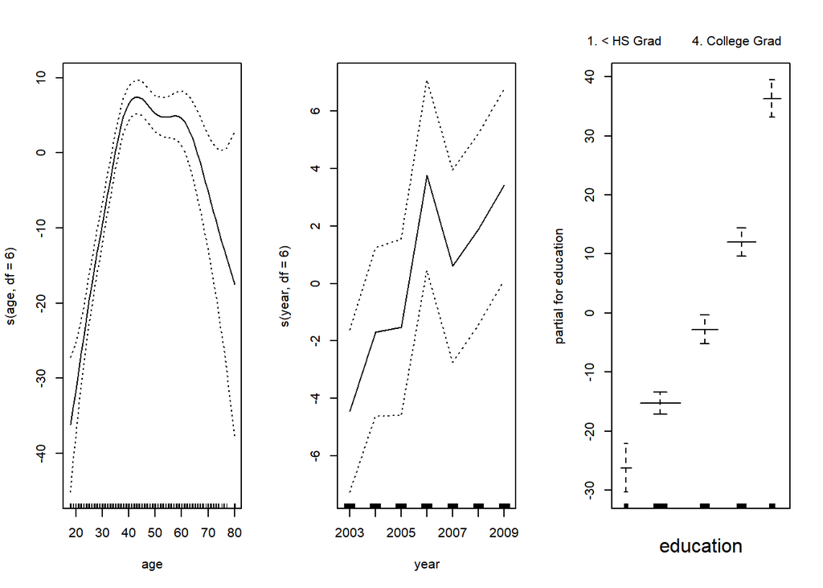

```r
gam1=gam(wage~s(age,df=6)+s(year,df=6)+education,data=Wage)

## Remember, GAM is taking only these 3 variables into account because we added those.

par(mfrow=c(1,3))
plot(gam1,se=T)
```

```r
#Salaries increase with age then decrease
#there seemed to be an general increase for year collected, except around 2007 (recession)
#Advanced Degrees are significant in increasing wage
```

### Model Test:

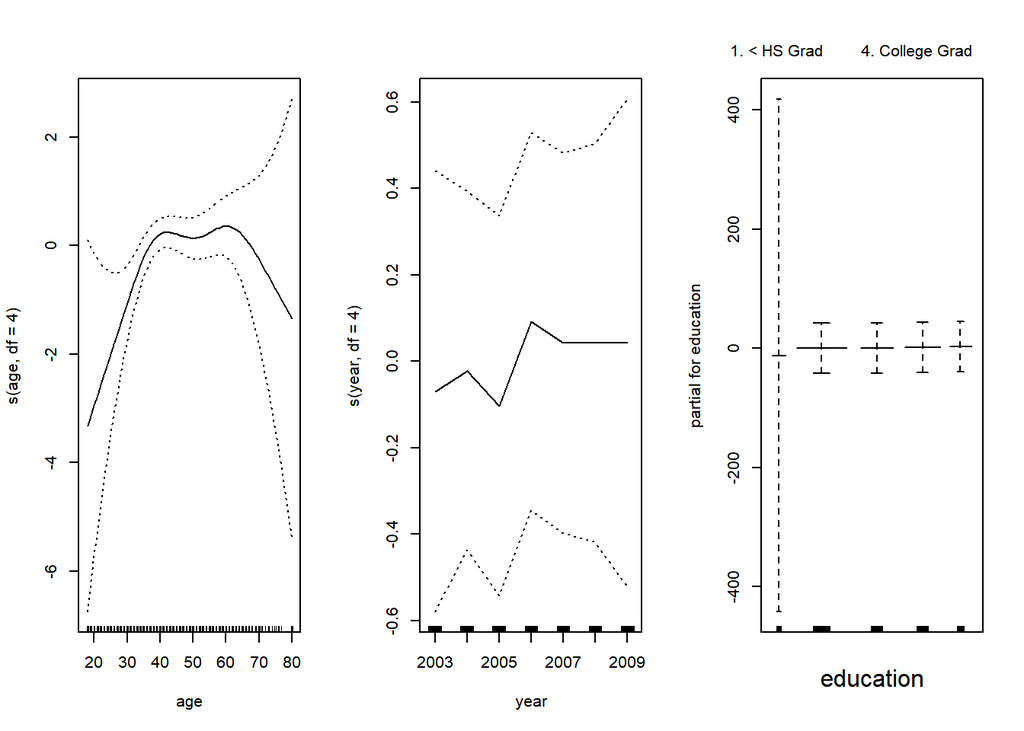

```r
#Let's observe qualitative output here  (Will do quantitative in comprehensive example)
#By using I() we are converting the response to be above $250 Yes/No (1/0)
logitgam1=gam(I(wage>250)~s(age,df=4)+s(year,df=4)+education,data=Wage, family=binomial)
par(mfrow=c(1,3))
plot(logitgam1,se=T)
```

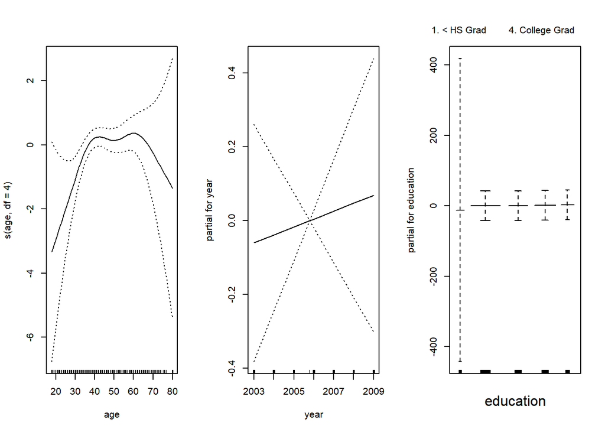

```r
#THe above is very similar, except the predicted variable is the logit. Basically if it over 0, it does meet above $250k. Also note, No one with less than a HS Grad education makes over $250k in our data, so none is predicted.

#Note:Plot for Year variable we can see that the error bands are quiet wide and broad.This might be an indication that our Non linear function fitted for ‘Year’ variable is not significant.

#Let's test to see if changing year to be linear matters:
logitgam2<-gam(I(wage >250) ~ s(age ,df=4)+ year + education , data =Wage, family = binomial)
par(mfrow=c(1,3))
plot(logitgam2,se=T)
```

```r
#see in the 2nd plot the year is a straight line now. That's because we models added a linear regression model this time. Let's find out if it's better that way.
```